# Data Visualisation Notebook

# R for Data Science

## Chapter 3: Data Visualisation

### 3.1 Introduction

#### 3.1.1 Prerequisites

```r
library(tidyverse)
```

### 3.2 First Steps

#### 3.2.1 The mpg dataframe

```r
mpg
```

| manufacturer | model | displ | year | cyl | trans | drv | cty | hwy | fl | class |
| --- | --- | --- | --- | --- | --- | --- | --- | --- | --- | --- |
| audi | a4 | 1.8 | 1999 | 4 | auto(l5) | f | 18 | 29 | p | compact |
| audi | a4 | 1.8 | 1999 | 4 | manual(m5) | f | 21 | 29 | p | compact |
| audi | a4 | 2.0 | 2008 | 4 | manual(m6) | f | 20 | 31 | p | compact |
| audi | a4 | 2.0 | 2008 | 4 | auto(av) | f | 21 | 30 | p | compact |
| audi | a4 | 2.8 | 1999 | 6 | auto(l5) | f | 16 | 26 | p | compact |
| audi | a4 | 2.8 | 1999 | 6 | manual(m5) | f | 18 | 26 | p | compact |
| audi | a4 | 3.1 | 2008 | 6 | auto(av) | f | 18 | 27 | p | compact |
| audi | a4 quattro | 1.8 | 1999 | 4 | manual(m5) | 4 | 18 | 26 | p | compact |
| audi | a4 quattro | 1.8 | 1999 | 4 | auto(l5) | 4 | 16 | 25 | p | compact |
| audi | a4 quattro | 2.0 | 2008 | 4 | manual(m6) | 4 | 20 | 28 | p | compact |

[output cut: 224 more lines]

#### 3.2.2 Creating a ggplot

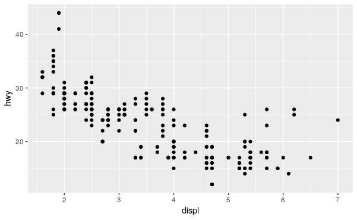

```r
ggplot(data = mpg) +
  geom_point(mapping = aes(x = displ, y = hwy))
```

#### 3.2.4 Exercises

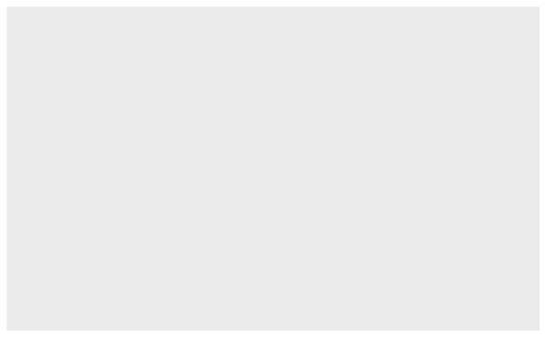

```r
# Nothing appears
ggplot(data = mpg)
```

```r
# How many rows are in mpg?
nrow(mpg)
```

```
[1] 234
```

```r
# How many columns?
ncol(mpg)
```

```
[1] 11
```

What does the drv variable describe? Read the help for ?mpg to find out.

```r
?mpg
# drv: f = front-wheel drive, r = rear wheel drive, 4 = 4wd
```

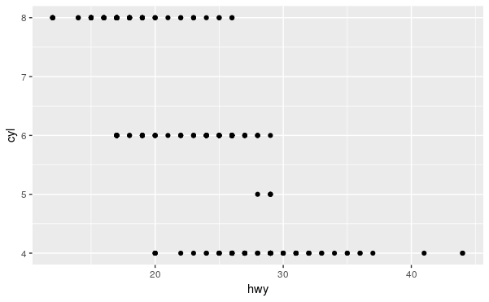

```r
# a scatterplot of hwy vs cyl.
ggplot(data = mpg) +
  geom_point(mapping = aes(x = hwy, y = cyl))
```

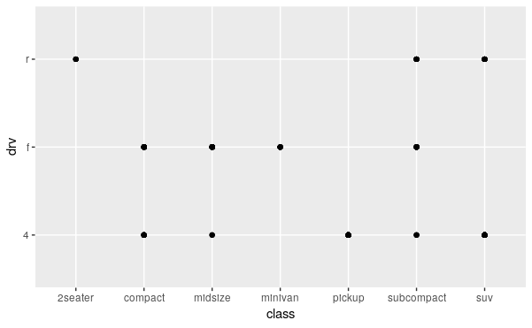

```r
# What happens if you make a scatterplot of class vs drv? Why is the plot not useful?
ggplot(data = mpg) +
  geom_point(mapping = aes(x = class, y = drv))
```

```r
# This plot is not useful because the values of both axes are non-numerical
```

### 3.3 Aesthetic mappings

aesthetic - a visual property of the objects in your plot

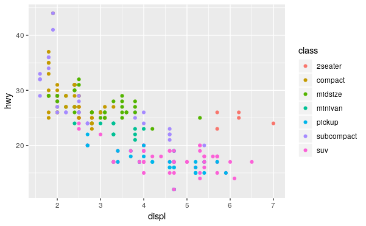

```r
# plots displ vs hwy with class differentiated with color (legend included)
ggplot(data = mpg) +
  geom_point(mapping = aes(x = displ, y = hwy, color = class))
```

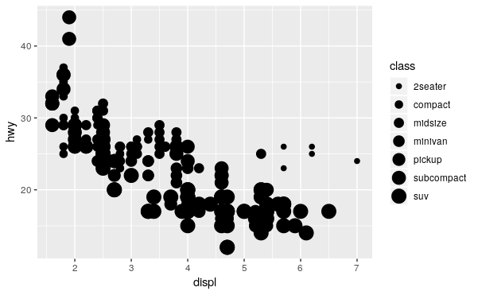

```r
# plots displ vs hwy with class differentiated by size (legend included)
ggplot(data = mpg) +
  geom_point(mapping = aes(x = displ, y = hwy, size = class))
```

```r
# problematic because size is not easily differentiated visually
```

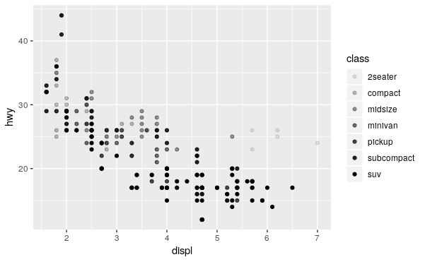

```r
# Left
ggplot(data = mpg) +
  geom_point(mapping = aes(x = displ, y = hwy, alpha = class))
```

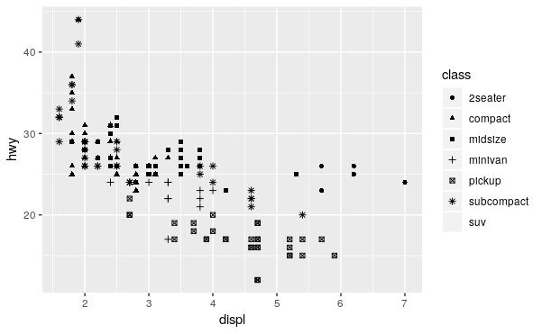

```r
# Right
ggplot(data = mpg) +
  geom_point(mapping = aes(x = displ, y = hwy, shape = class))
```

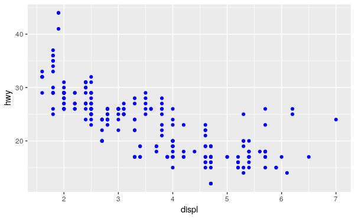

```r
ggplot(data = mpg) +
  geom_point(mapping = aes(x = displ, y = hwy), color = "blue")
```

#### 3.3.1 Exercises

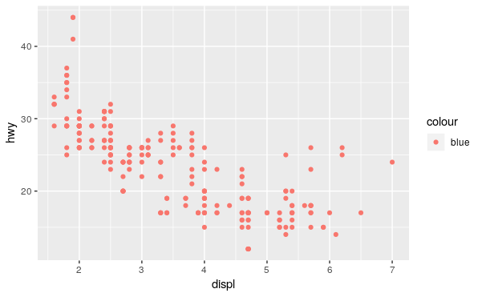

```r
ggplot(data = mpg) +
  geom_point(mapping = aes(x = displ, y = hwy, color = "blue"))
```

```r
# color = "blue" fulfills the class argument in aes() function, instead of a argument within geom_point() function (which is where the color of the points will change).
```

```r
# Which variables in mpg are categorical? Which variables are continuous? (Hint: type ?mpg to read the documentation for the dataset). How can you see this information when you run mpg?
?mpg
mpg # when you run mpg if the values are a number they are continuous, if the values are names, they are categorical
```

| manufacturer | model | displ | year | cyl | trans | drv | cty | hwy | fl | class |
| --- | --- | --- | --- | --- | --- | --- | --- | --- | --- | --- |
| audi | a4 | 1.8 | 1999 | 4 | auto(l5) | f | 18 | 29 | p | compact |
| audi | a4 | 1.8 | 1999 | 4 | manual(m5) | f | 21 | 29 | p | compact |
| audi | a4 | 2.0 | 2008 | 4 | manual(m6) | f | 20 | 31 | p | compact |
| audi | a4 | 2.0 | 2008 | 4 | auto(av) | f | 21 | 30 | p | compact |
| audi | a4 | 2.8 | 1999 | 6 | auto(l5) | f | 16 | 26 | p | compact |
| audi | a4 | 2.8 | 1999 | 6 | manual(m5) | f | 18 | 26 | p | compact |
| audi | a4 | 3.1 | 2008 | 6 | auto(av) | f | 18 | 27 | p | compact |
| audi | a4 quattro | 1.8 | 1999 | 4 | manual(m5) | 4 | 18 | 26 | p | compact |
| audi | a4 quattro | 1.8 | 1999 | 4 | auto(l5) | 4 | 16 | 25 | p | compact |
| audi | a4 quattro | 2.0 | 2008 | 4 | manual(m6) | 4 | 20 | 28 | p | compact |

[output cut: 224 more lines]

categorical: manufacturer model, trans, drv, fl, class continuous: displ, year, cyl, cty, hwy

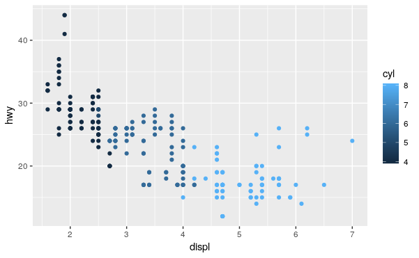

```r
# Map a continuous variable to color, size, and shape
# color
ggplot(data = mpg) +
  geom_point(mapping = aes(x = displ, y = hwy, color = cyl))
```

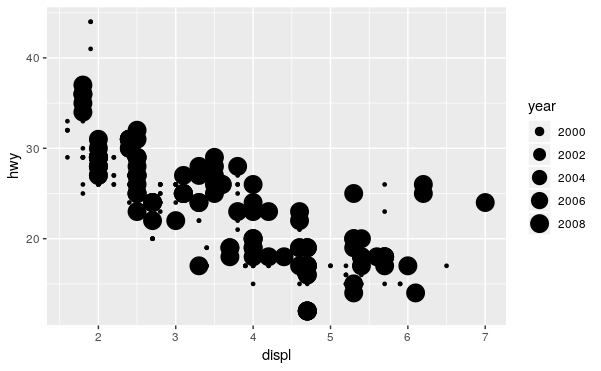

```r
# size:
ggplot(data = mpg) +
  geom_point(mapping = aes(x = displ, y = hwy, size = year))
```

```r
# shape: error cannot map continuous variable to shape
ggplot(data = mpg) +
  geom_point(mapping = aes(x = displ, y = hwy, shape = cty))
```

```
Error: A continuous variable can not be mapped to shape
```

Continuous vs categorical plotting using shape, size, and color: continuous plot of color has a gradient bar instead of categorical plot of color has diff colored dots continuous plot of size has the same dots as categorical plot continuous plot of shape cannot be plotted

What does the stroke aesthetic do? What shapes does it work with? (Hint: use ?geom_point)

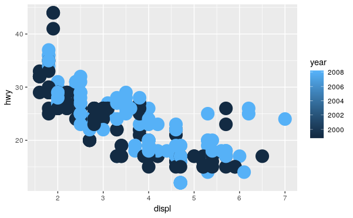

```r
?geom_point
# stroke aesthetic modifies size of the points
ggplot(data = mpg) +
  geom_point(mapping = aes(x = displ, y = hwy, color = year), stroke = 5)
```

What happens if you map an aesthetic to something other than a variable name, like aes(colour = displ < 5)? Note, you’ll also need to specify x and y.

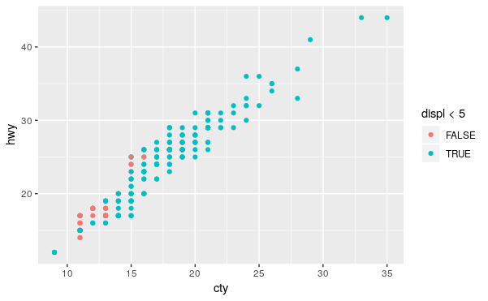

```r
ggplot(data = mpg) +
  geom_point(mapping = aes(x = cty, y = hwy, color = displ < 5))
```

```r
# instead of differentiating the values of all displ options, the colors differ between what is less than 5 (True) and what is greater than or equal to 5 (False)
```